# PH784 Advanced Social Epidemiology: Methods

Week 5: Causal Estimand

Koichiro Shiba

kshiba@bu.edu

Boston University School of Public Health

October 6, 2025

## Today’s Plan

1. Causal estimand big picture
2. Hypothetical interventions
   - Treatment regimen
3. Summarizing population health

## Causal Inference: Big Picture

[figure not shown]

- Often too much emphasis on identification and estimation
- Causal estimand is equally (or even more) important
  - Defining a question you want to answer
    - Statistical estimand under the identification assumptions

> “We make only one point in this article. Every quantitative study must be able to answer the question: what is your estimand? The estimand is the target quantity—the purpose of the statistical analysis. Much attention is already placed on how to do estimation; a similar degree of care should be given to defining the thing we are estimating.”(Lundberg et al. 2021)

## Starting With Causal Estimand

[figure not shown]

**Why does it matter?**

- Wrong interpretation
- Wrong analytic approach
- Comparability (e.g., meta analysis)

## Causal Estimand

### What we have covered so far

- $E[Y^{a=1} - Y^{a=0}]$
  - Average Treatment Effect (ATE)
    - Comparing the potential outcome had everyone been exposed vs had nobody been exposed
    - More generally, $E[Y^{a} - Y^{a^*}]$ for different exposure values
- $E[Y^{a=1} - Y^{a=0}|L=l]$
  - Conditional Average Treatment Effect (CATE)
    - Interpretation among individuals with $L=l$
    - Outcome regression typically estimates CATEs

[figure not shown]

## Anatomy of Causal Estimand

### Bare minimum

$$E[Y^{a=1} - Y^{a=0}]$$

- Defined by:
  1. Outcome: $Y$
  2. Exposure: $A$
  3. Time interval between $A$ and $Y$
     - The effect of physical activity on obesity tomorrow vs 3 years later
       - Ignored in the sloppy expression: “the effect of A on Y”
- Different “effects” are often inappropriately:
  - Compared
  - Synthesized in meta analyses

## Anatomy of Causal Estimand

### Closer look

$$E[Y^{a=1} - Y^{a=0}]$$

- Summarized comparison of individual potential outcome
- Comparison of summarized population health
  - $E[Y^{a=1}]-E[Y^{a=0}]$

**This comparison is defined based on the choice of:**

1. Hypothetical interventions to define potential outcomes
2. Study population (e.g., mean among whom?)
3. Reference (e.g., $a=0$)
4. Summary measure (e.g., mean difference)

## Anatomy of Hypothetical Intervention

$$E[Y^{a=1}]-E[Y^{a=0}]$$

- Comparison of summarized population health
  - What are we comparing?
  - $E[Y^a]$: Expected value of the outcome that would have observed had everyone received $a$
    - Mean potential outcome under a hypothetical population intervention

**A hypothetical intervention is defined based on:**

1. A well-defined treatment (what is $a=1$?)
2. Direction of change
3. Treatment regimen (how do we change the treatment $a$?) <sup>1</sup>
[^1]: People often use the term “regime” and “regimen” interchangeably.

## Defining Hypothetical Interventions

### Point 1: Well-defined treatment

$$E[Y^{a=1}]-E[Y^{a=0}]$$

- Defining an exposure $A$ that corresponds to real-life interventions $A \rightarrow a$
  - Consistency assumption
- “Effects of composite social vulnerability index (SVI) scores”
  - “Had everyone received one point higher SVI score,…”
    - Multiple versions of treatment
      - Effects of what? Changing poverty? Education? Single-parent households? English fluency?
    - Interpretable as a stochastic population intervention (VanderWeele and Hernan 2013)
      - But less intuitive interpretation

## Defining Hypothetical Interventions

### Point 2: Directionality

$$E[Y^{a=1}]-E[Y^{a=0}]$$

- When we have a well-defined exposure $A$
  - A well-defined interventions to change the exposure $A \rightarrow a$
    - Directionality?
    - Increasing/giving $A$ vs Decreasing/removing $A$
- RCT
  - e.g., initiating treatment
  - Clear directionality of change

[figure not shown]

- Observational study
  - Mixture of initiation and cessation
  - Unclear directionality

[figure not shown]

## Defining Hypothetical Interventions

### Point 2: Directionality

[figure not shown]

- $E[Y^{a=1}]-E[Y^{a=0}]$
  - e.g., What would happen if we forced everyone to smoke ($a=1$) vs not to smoke ($a=0$)?
  - Involves forcing non-smokers to smoke (assigning $a=1$ for those with $A=0$)
- Typically, only one direction is of interest
  - Decreasing/removing a harmful exposure
  - Increasing/giving a beneficial exposure

**How do we specify the direction of change in observational studies?**

1. Conditioning on pre-baseline exposure values
   - via study design or analytically
2. Narrowing an inferential target based on baseline exposure values (e.g., ATT)

## Specifying Directionality for Hypothetical Interventions

### 1. Conditioning on pre-baseline exposure values

[figure not shown]

- Conditioning on pre-baseline exposure values
  - Looking at individuals who originally had the same exposure levels
  - Captures “changes” in the exposure
- Approach 1: Restricting analytic sample based on pre-baseline exposure values
  - Study design
  - e.g., Analyzing only those who were unexposed before the baseline
    - Effects of treatment initiation

## Specifying Directionality for Hypothetical Interventions

### 1. Conditioning on pre-baseline exposure values

- Approach 2: Analytically control for pre-baseline exposure (VanderWeele et al. 2020)

[figure not shown]

- $E[Y_2|A_1, A_0, L_0]=\beta_0 + \beta_1A_1 + \beta_2A_0 + \gamma L_0$
  - $\beta_1$
    - $E[Y_2|A_1=1, A_0, L_0]-E[Y_2|A_1=0, A_0, L_0]$
    - Association between $A_1$ and $Y_2$ conditional on $A_0$ and $L_0$
      - Among those with $A_0=0$: the effect of treatment initiation
      - Among those with $A_0=1$: the effect of treatment cessation
        - Assumed irrelevance of the directionality

## Specifying Directionality for Hypothetical Interventions

### 1. Conditioning on pre-baseline exposure values

- Approach 2: Analytically control for pre-baseline exposure (VanderWeele et al. 2020)

[figure not shown]

- $E[Y_2|A_1, A_0, L_0]=\beta_0 + \beta_1A_1 + \beta_2A_0 + \beta_3 A_1*A_0+ \gamma L_0$
  - $\beta_1$
    - $E[Y_2|A_1=1, A_0=0, L_0]-E[Y_2|A_1=0, A_0=0, L_0]$
    - Association between $A_1$ and $Y_2$ among $A_0=0$ conditional on $L_0$
  - $\beta_1 + \beta_3$
    - $E[Y_2|A_1=1, A_0=1, L_0]-E[Y_2|A_1=0, A_0=1, L_0]$
    - Association between $A_1$ and $Y_2$ among $A_0=1$ conditional on $L_0$
  - The model explicitly distinguishes initiation vs cessation effects

## Specifying Directionality for Hypothetical Interventions

### 2. Narrowing an inferential target based on baseline exposure

[figure not shown]

- Conditioning on pre-baseline exposure
  - e.g., the initiation effect: $E[Y_2^{a_1=1}-Y_2^{a_1=0}|A_0=0]$
    - Conditioning on baseline exposure?

[figure not shown]

## Summary 1

- Well-defined intervention
  - Well-deinfed treatment
  - Directionality
    - Conditioning on pre-baseline treatment
      - Study design
      - Covariate adjustment
    - Conditioning on baseline treatment
      - ATT, ATC

Next, treatment regimen

## Anatomy of Hypothetical Intervention

$$E[Y^{a=1}]-E[Y^{a=0}]$$

- Comparison of summarized population health
  - What are we comparing?
  - $E[Y^a]$: Expected value of the outcome that would have observed had everyone received $a$
    - Mean potential outcome under a hypothetical population intervention

**A hypothetical intervention is defined based on:**

1. A well-defined treatment (what is $a=1$?)
2. Direction of change
3. Treatment regimen (how do we change the treatment $a$?)

## Baseline Treatment and Treatment Trajectories

### RCT

[figure not shown]

- Confounding for the effects of actual treatment $A$
- Intention-to-treat (ITT) analysis
  - Effect of random assignment $X$ is not confounded
  - Intervention: “assigning” treatment (vs forcing it)
- Non-adherence leads to discordance between assignment $X$ and actual treatment $A$
  - Potentially attenuated contrast in treatment trajectories (Toh and Hernán 2008)
    - “No effect of $X$” $\neq$ “no effect of $A$”

## Baseline Treatment and Treatment Trajectories

### Observational study

[figure not shown]

- Association between baseline exposure $A_0$ and outcome $Y$, adjusting for confounders $L_0$
  - Unbiased estimate of the effect of $A_0$
    - $E[Y^{a_0=1}-Y^{a_0=0}|L_0]$
  - Same non-adherence problem for subsequent exposure (e.g., $A_1$)
- Observational analogue of ITT effects (Hernán and Robins 2016)
  - Effect of forcing $A_0$ while allowing them to deviate over time (single-point intervention)
  - Effect of random assignment with perfect adherence at baseline
    - Determined by post-baseline exposure trajectories ($A_1^{a_0}$)
    - “No effect of $A_0$” $\neq$ “no effect of $A$ at all”

## Baseline Treatment and Treatment Trajectories

### Observational study

[figure not shown]

- Analysis of baseline exposure $A_0$
  - Effect of single-point intervention
    - i.e., “boosting” exposure at baseline
  - Non-adherence over time

**What if they remain treated over time?**

- Effect of “sustained” intervention
  - e.g., $E[Y^{a_0=1, a_1=1}-Y^{a_0=0, a_1=0}]$
    - remain treated vs remain untreated
  - viewing $A$ as a time-varying exposure

## Analysis of Time-Varying Exposures

[figure not shown]

- Estimating effects of a time-varying exposure
  - Joint exposure to $A_0$ and $A_1$
  - $M_1$: covariates affected by baseline exposure $A_0$
    - Should not be conditioned on as a mediator for the effect of $A_0$
    - Should be conditioned on as a confounder for the effect of $A_1$

**Causal inference for time-varying exposures**

- Useful when interested in considering joint intervention across different time points
- Difficult in the presence of time-dependent confounding
  - Cannot be addressed by conventional regression-based covariate adjustment
  - Use g-methods (e.g., g-computation) (Naimi et al. 2017)

## Analysis of Time-Varying Exposures

### Example: Social participation and depressive symptoms among older adults (Shiba et al. 2021)

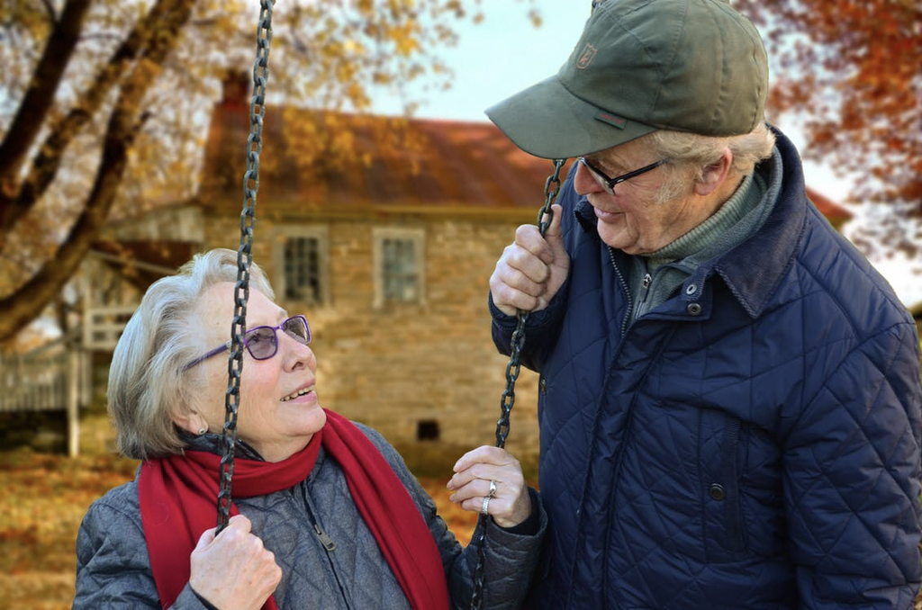

- Older adults in Japan (≥65 years old)
  - Three waves: 2010, 2013, and 2016
- Exposure: Social participation in 2010 and 2013
- Outcome: Depressive symptoms in 2016

[figure not shown]

**Effect estimation via TMLE**

1. Baseline exposure analysis
   - Single-point interention in 2010
2. Time-varying exposure analysis
   - Sustained intervention in 2010 and 2013

## Analysis of Time-Varying Exposures

### Example: Social participation and depressive symptoms among older adults (Shiba et al. 2021)

- Sustained participation is (obviously) more effective
  - Some null results for baseline exposure (e.g., volunteering)
    - Still effective if sustained

[figure not shown]

## Analysis of Time-Varying Exposures

### Common misconceptions

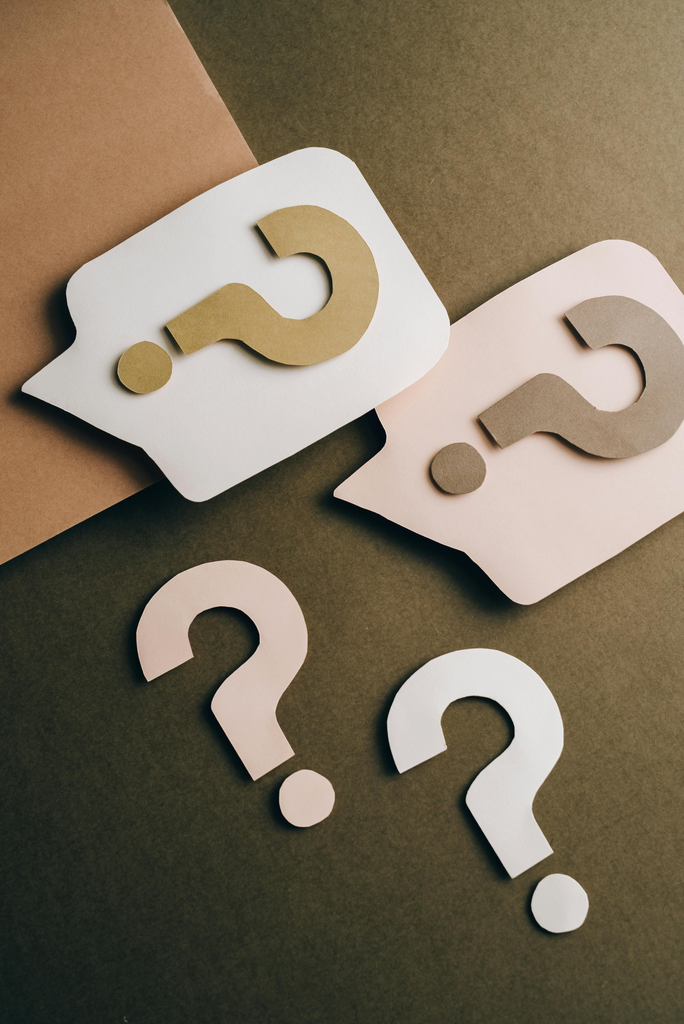

- Should we use g-methods whenever an exposure is time-varying conceptually?
  - No, unless you are specifically interested in the effects of joint interventions
    - and when there is time-dependent confounding
- Is the simple baseline exposure analysis biased?
  - No, it is a valid estimate for the single-point intervention

**Analysis of time-varying exposures should be motivated by:**

- Interest in joint interventions
  - Clarify the estimand of interest
  - Specify treatment regimen of interest (e.g., one-time boost vs sustained treatment)
- Plausible time-dependent confounding
  - i.e., exposure-induced confounders for the subsequent exposure

## Analysis of Time-Varying Exposures

### Motivating research on joint interventions

[figure not shown]

- Temporal change in exposure
  - “Non-adherence” problem
  - Sustained treatment $\neq$ single-point intervention

[figure not shown]

- Sustained treatment ($a_0=a_1=1$) > single-point intervention ($a_0=1$)
  - Short-term effect of $\color{#be2f3a}{a_1}$?
  - Accumulated effect ($\color{#457b9d}{a_0} + \color{#be2f3a}{a_1}$)?
  - Synergistic effect ($\color{#457b9d}{a_0} * \color{#be2f3a}{a_1}$)?
    - Insights into etiology

## Analysis of Time-Varying Exposures

### Motivating research on joint interventions

[figure not shown]

- Sustained treatment ($a_0=a_1=1$) > single-point intervention ($a_0=1$)
  - Short-term effect of $\color{#be2f3a}{a_1}$?
  - Accumulated effect ($\color{#457b9d}{a_0} + \color{#be2f3a}{a_1}$)?
  - Synergistic effect ($\color{#457b9d}{a_0} * \color{#be2f3a}{a_1}$)?

| Hypothetical Intervention | Regimen a0 | Regimen a1 | Ref a0 | Ref a1 |
| --- | --- | --- | --- | --- |
| Baseline treatment | 1 |  | 0 |  |
| Sustained treatment (A) | 1 | 1 | 0 | 0 |
| Discontinued treatment (B) | 1 | 0 | 0 | 0 |
| Delayed treatment (C) | 0 | 1 | 0 | 0 |

- Typology of “joint interventions”
  - $B>0$: Long-lasting effects
    - e.g., $A=B>0$: One-time boost is sufficient
  - $C>0$: Presence of immediate effect
  - $B+C≠A$: Synergistic effect
    - e.g., $A>0$ & $B=C=0$: effective only when sustained
- Application in social epi?

## Analysis of Time-Varying Exposures

### Motivating research on joint interventions

[figure not shown]

**Competing hypotheses in life course epidemiology**

1. Accumulation model ($SES_c \rightarrow Y_a + SES_a \rightarrow Y_a$)
2. “Chain-of-risk” model ($SES_c \rightarrow SES_a \rightarrow Y_a$)
3. Sensitive period model (only $SES_c \rightarrow Y_a$)
4. Stress sensitization model ($SES_c$ modifies $SES_a \rightarrow Y_a$)
- “Time-varying exposure analysis” can be used for:
  - Time-varying values of the same exposure: $SES_{child}$ and $SES_{adult}$ (Nandi et al. 2012)
  - Distinct exposures at different time points: $ACE_{child}$ and $SES_{adult}$ (Yazawa et al. 2022)
    - Can also be viewed as mediation analysis (Howe et al. 2016)

## Extending “Treatment Regimen”

- Single-point intervention ($a_0=1$)
- Sustained treatment ($a_0=a_1=1$)
  - Everyone gets the same pre-specified treatment
  - Static treatment regimen
- Dynamic treatment regimen
  - Treatment decision is dependent on past covariates
  - e.g., Continue treatment if depressive symptoms scores ≥ 5 points

Static treatment regimen

| $a_0$ | $L^{a_0}_1$ | $a_1$ |
| --- | --- | --- |
| 1 | 8 | 1 |
| 1 | 3 | 1 |

Dynamic treatment regimen

| $a_0$ | $L^{a_0}_1$ | $A^{+g}_1$ |
| --- | --- | --- |
| 1 | 8 | 1 |
| 1 | 3 | 0 |

## Extending “Treatment Regimen”

- Example from Week #2 (slides #8-10)
  - Effect of a binary (protective) social exposure $A$ on a disease $Y$: RR=0.98
  - Baseline outcome risk among the unexposed: 10%

| # Intervened | # Cases | # Cases if Intervened | # Cases Prevented |
| --- | --- | --- | --- |
| 1,000 | 100 | 98 | 2 |
| 10,000 | 1,000 | 980 | 20 |
| 100,000 | 10,000 | 9,800 | 200 |

- Population impacts depend on “# intervened”
- “# intervened” is determined by
  - Exposure distributions (e.g., genetic mutation vs neighborhood environment)
  - Scope of interventions (e.g., clinical practice vs policies)

## Extending “Treatment Regimen”

- Assigning a *constant* level of exposure
  - Unrealistic intervention
    - Especially for continuous exposures
  - Ignores the “# intervened” (hence, population impacts)

[figure not shown]

## Extending “Treatment Regimen”

- Modifies the exposure *distribution*
  - Stochastic treatment regimen (Muñoz and Van Der Laan 2012)
    - e.g., decreasing exposure by a fixed amount
    - e.g., decreasing exposure by 10%
  - Can be compared with the “natural course” (Rudolph et al. 2022)

[figure not shown]

## Extending “Treatment Regimen”

### Applications of stochastic interventions approach

- Hypothetical air pollutant interventions (e.g., reducing PM2.5 by 10%) (Garcia et al. 2019)
- Reducing disparities in adverse childhood experience (Lam-Hine et al. 2024)
- Limiting neighborhood alcohol outlet density to prevent binge drinking (Ahern et al. 2016)

**Stochastic treatment regimen**

- Potentially more realistic intervention (Westreich 2017)
  - More relevant contrast when compared with the “natural course”
- Insights into population-level impacts

## Real-Life Challenges in “Selling” Stochastic Effects

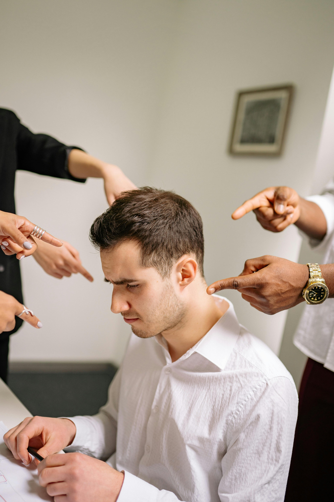

- “Hypothetical intervention that reduces the exposure by 50%”
  - “Arbitrary and unrealistic interventions!”
    - Yes, it is. To some extent.
    - Is “forcing everyone to be exposed” less arbitrary and more realistic?
  - “Small effect size!”
    - Of course, there is a massive difference in outcome when thinking about the extreme contrast between “all exposed” vs “all unexposed”
    - Is the big effect size for a rare exposure meaningful as a population impact metric?

## Summary 2

- Baseline exposure analysis
  - Single-point intervention (one-time-boost)
  - Observational analogue of ITT effects
    - Interpretatin in the presence of “non-adherence”?
- Time-varying treatment analysis
  - Joint intervention (e.g., sustained treatment)
    - Time-dependent confounding
  - Just because your exposure is conceptually “time-varying”, doesn’t necessarily mean you need fancy methods!
- Dynamic treatment regimen
  - Adaptive rules for treatment decisions
- Stochastic interention
  - More realistic changes in population distributions of an exposure
  - Population impacts

## Let’s Step Back: Anatomy of Causal Estimand

$$E[Y^{a=1}]-E[Y^{a=0}]$$

**This comparison is defined based on the choice of:**

1. Hypothetical interventions to define potential outcomes
   - Well-defined treatment, directionality, regimen (time-varying, dynamic, stochastic)
2. Study population (e.g., mean among whom?)
   - Subpopulation: ATE vs CATE, ATT, ATC, etc
3. Reference (e.g., $a=0$)
   - vs natural course
4. Summary measure (e.g., mean difference)

## Summarizing Changes in Population Health

- Continuous outcome
  - Mean difference: $E[Y^{a=1}]-E[Y^{a=0}]$
- Binary outcome
  - Risk/prevalence/rate difference: e.g., $Pr[Y^{a=1}=1]-Pr[Y^{a=0}=1]$
  - Risk/prevalence/rate/odds ratio: e.g., $Pr[Y^{a=1}=1]/Pr[Y^{a=0}=1]$

**Alternative ways to summarize population health?**

## Summarizing Changes in Population Health

- Trajectories
  - Repeated outcome measures
    - Mixed-effect model
    - GEE
  - e.g., “speed” of cognitive decline (Weuve et al. 2018)

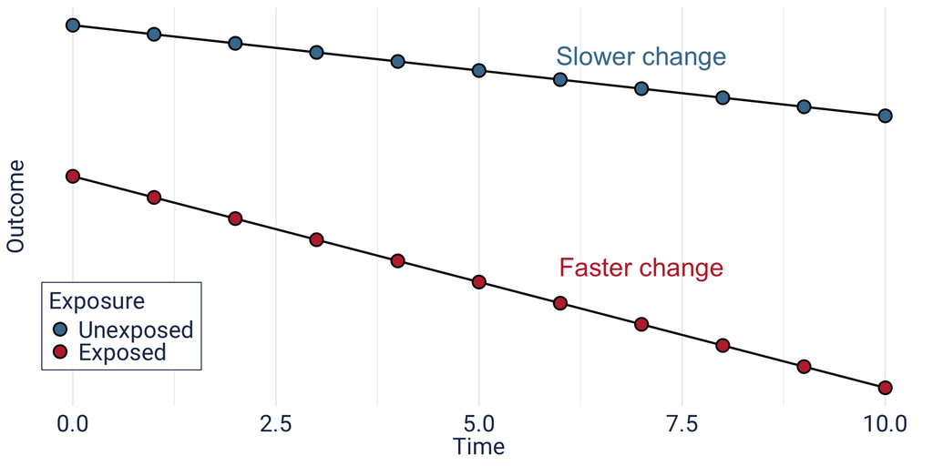

## Summarizing Changes in Population Health

### Distribution beyond mean

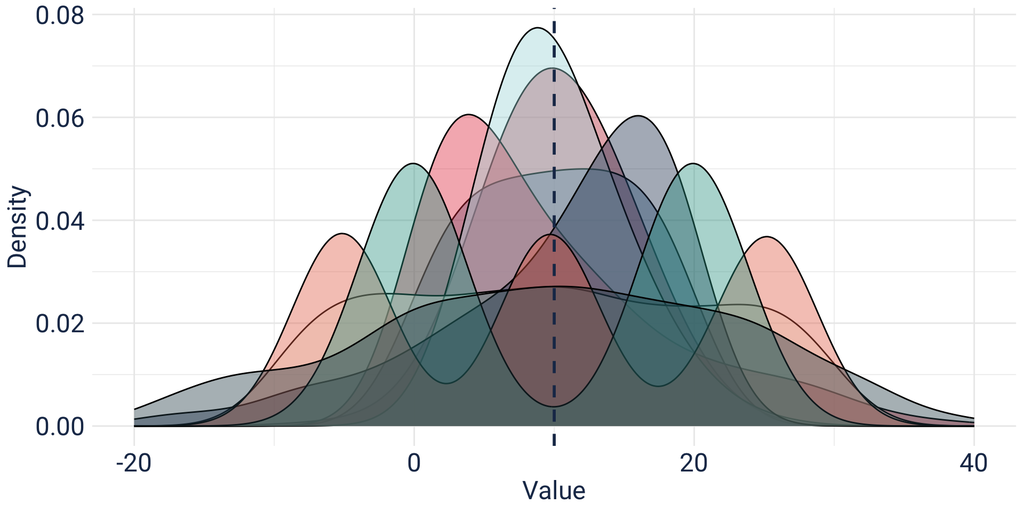

- Mean is just one way of summarizing a full distribution
  - Different distributions with the same mean
    - e.g., Example by [Thomas J Pfaff](https://briefedbydata.substack.com/p/same-mean-different-distribution)

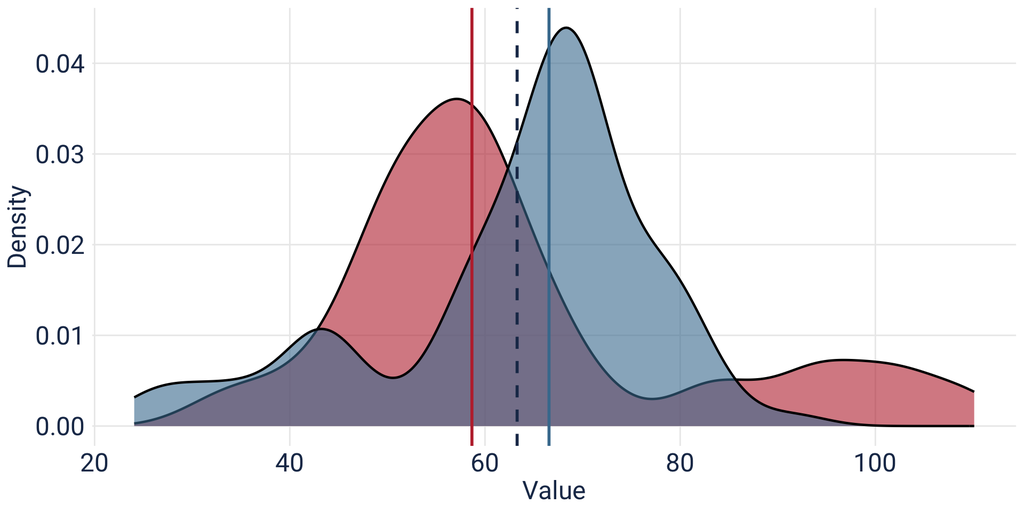

- Change in different part of the distribution
  - e.g., Change in median
    - Quantile regression
      - Excellent tutorial by Khadka et al. (2025)

## Summarizing Changes in Population Health

### Distribution beyond mean

[figure not shown]

- Hypothetical interventions may have:
  - Same “effect” on average population health
  - Different implications for distributions
    - i.e., health disparities

Shifting the definition of “causal effect”

- “How would the hypothetical intervention change health disparities?”
  - e.g., $(E[Y^{A_g}|SES=high] - E[Y^{A_g}|SES=low]) - (E[Y|SES=high] - E[Y|SES=low])$
    - for stochastic intervention $A_g$
  - “The gap-closing estimand” (Lundberg 2024)
  - Example: Social isolation and social inequalities in all-cause mortality (Lunar et al. 2025)

## Summary 3

- Causal effect is a contrast of two populatin health under hypothetical/counterfactual scenarios
  - Mean difference/ratio is not the only way to summarize population health
- Outcome trajectories
- Distributional shift
- Change in disparities

## Assignment

- Problem set #5
- Reading quiz based on:
  1. VanderWeele TJ, Knol MJ. A tutorial on interaction. Epidemiologic methods. 2014 Dec 1;3(1):33-72.
  2. Ward JB, Gartner DR, Keyes KM, Fliss MD, McClure ES, Robinson WR. How do we assess a racial disparity in health? Distribution, interaction, and interpretation in epidemiological studies. Annals of epidemiology. 2019 Jan 1;29:1-7.

## References

Ahern J, Colson KE, Margerson-Zilko C, Hubbard A, Galea S. Predicting the population health impacts of community interventions: The case of alcohol outlets and binge drinking. American journal of public health. 2016;106(11):1938–43.

Garcia E, Urman R, Berhane K, McConnell R, Gilliland F. Effects of policy-driven hypothetical air pollutant interventions on childhood asthma incidence in southern california. Proceedings of the National Academy of Sciences. 2019;116(32):15883–8.

Greifer N, Stuart EA. Choosing the causal estimand for propensity score analysis of observational studies. arXiv preprint arXiv:210610577. 2021;

Hernán MA, Robins JM. Using big data to emulate a target trial when a randomized trial is not available. American journal of epidemiology. 2016;183(8):758–64.

Howe LD, Smith AD, Macdonald-Wallis C, Anderson EL, Galobardes B, Lawlor DA, et al. Relationship between mediation analysis and the structured life course approach. International Journal of Epidemiology. 2016;45(4):1280–94.

Khadka A, Hebert JL, Glymour MM, Jiang F, Irish A, Duchowny KA, et al. Quantile regressions as a tool to evaluate how an exposure shifts and reshapes the outcome distribution: A primer for epidemiologists. American Journal of Epidemiology. 2025;194(7):2075–84.

Lam-Hine T, Bradshaw P, Allen A, Omi M, Riddell C. A hypothetical intervention to reduce inequities in anxiety for multiracial people: Simulating an intervention on childhood adversity. American Journal of Epidemiology. 2024;193(12):1750–7.

Lunar FR, Kondo N, Honda Y, Nakagomi A, Komura T, Inoue K, et al. Sociodemographic heterogeneity in the association between social isolation and all-cause mortality among japanese older adults: JAGES longitudinal panel study. Lancet Reg Health West Pac. 2025 Oct;63.

Lundberg I. The gap-closing estimand: A causal approach to study interventions that close disparities across social categories. Sociological Methods & Research. 2024;53(2):507–70.

Lundberg I, Johnson R, Stewart BM. What is your estimand? Defining the target quantity connects statistical evidence to theory. American Sociological Review. 2021;86(3):532–65.

Muñoz ID, Van Der Laan M. Population intervention causal effects based on stochastic interventions. Biometrics. 2012;68(2):541–9.

Naimi AI, Cole SR, Kennedy EH. An introduction to g methods. International journal of epidemiology. 2017;46(2):756–62.

Nandi A, Glymour MM, Kawachi I, VanderWeele TJ. Using marginal structural models to estimate the direct effect of adverse childhood social conditions on onset of heart disease, diabetes, and stroke. Epidemiology. 2012;23(2):223–32.

Rudolph JE, Cartus A, Bodnar LM, Schisterman EF, Naimi AI. The role of the natural course in causal analysis. American journal of epidemiology. 2022;191(2):341–8.

Shiba K, Kawahara T. Using propensity scores for causal inference: Pitfalls and tips. Journal of epidemiology. 2021;31(8):457–63.

Shiba K, Torres JM, Daoud A, Inoue K, Kanamori S, Tsuji T, et al. Estimating the impact of sustained social participation on depressive symptoms in older adults. Epidemiology. 2021;32(6):886–95.

Toh S, Hernán MA. Causal inference from longitudinal studies with baseline randomization. The international journal of biostatistics. 2008;4(1):22.

VanderWeele TJ, Hernan MA. Causal inference under multiple versions of treatment. Journal of causal inference. 2013;1(1):1–20.

VanderWeele TJ, Mathur MB, Chen Y. Outcome-wide longitudinal designs for causal inference: A new template for empirical studies. 2020;

Westreich D. From patients to policy: Population intervention effects in epidemiology. Epidemiology. 2017;28(4):525–8.

Weuve J, Barnes LL, De Leon CFM, Rajan KB, Beck T, Aggarwal NT, et al. Cognitive aging in black and white americans: Cognition, cognitive decline, and incidence of alzheimer disease dementia. Epidemiology. 2018;29(1):151–9.

Yazawa A, Shiba K, Inoue Y, Okuzono SS, Inoue K, Kondo N, et al. Early childhood adversity and late-life depressive symptoms: Unpacking mediation and interaction by adult socioeconomic status. Social psychiatry and psychiatric epidemiology. 2022;57(6):1147–56.